# Newark Flight Data

Malcolm Speight

2023-02-13

## Context

#### BI and data-driven decision making

The mangement team at Newark Airport know that there are a large number of variables that impact the running of their airport. Some they can control and others they can’t. Understanding which variables are important and which aren’t allows management to focus their attention on problem areas with confidence and apply their finite resources more efficiently.

Organisations are awash with data these days. Extracting value from the data-mountain can be a daunting task which can often lead to procrastination and a focus on business-as-usual (BAU) rather than change. Whilst BAU might “get the job done” in the short term, it doesn’t facilitate growth or the adoption of new and more efficient business practices.

Machine learning algorithms enables business to query large amounts of data and zero-in on the most crucial information within a mountain of inputs and then use that data to make predictions about the future based on historical patterns.

The machine learning techniques featured in this report will allow management to better understand their operating environment by providing statistical, fact based evidence as to which variables have the greatest impact on the running of the airport.

This knowledge will enable the management team at Newark Airport to take better informed decisions and identify areas for further research.

#### Domain knowledge and the business context

I received a data set from Newark Liberty International Airport (airport code “EWR”) which contains departing flights from EWR in the year 2017.

The airport is located 10 miles south-west of New York City (NYC) and is one of three international airports serving NYC, along with La Guardia and JFK airports. Of the three, EWR is the second busiest. In 2017 over 43 million passengers traveled through the airport compared to 55 million at JFK and 30 million at La Guardia.

In addition to 2017 flight departures, datasets relating to airports, airlines, planes and weather records for all three NYC airports were provided to me.

Newark Airport believe poor weather conditions are causing too many delays to departing flights. They wish to ascertain if this assumption is correct and if it is, they would look to improve facilities at the airport to lessen the impact of weather related delays if possible.

Delays to the departure times of airlines operating out of Newark Airport clearly have business implications for the airport. If delays persist or become endemic, passengers will choose to fly from alternative airports. So too with cargo planes. Persistent delays may see more business shift to La Guardia, JFK or to other airports on the eastern seaboard of the US.

Airport management are clearly concerned about departure delays and the causes of delay. The economic consequences of delay are significant as is reputational damage to the airport if it becomes associated with delayed flights. Social media now allows each passengers to broadcast their grievances to the world without filter. Reacting to passenger grievances after the event may be too late. It’s best to manage points of conflict and inefficiency before a crises erupts. Newark airport management can be seen to be proactive in their attempts to understand the source of delays and so work to eliminate or reduce those delays where possible.

As such I have been asked by Newark Airport to use the data provided to answer the following business questions:

- what effect does the weather have on flight departure delays?
- how serious are weather related delays?
- what types of weather impacts delays the most?
- what other factors impact delays?
- how important are weather factors in comparison to these other factors?
- compare delays at Newark Airport to the other NYC airports.

## Data

#### Internal and external data sources

**Internal data**  
Five data sets were provided to me by Newark Airport:

*flights* - contained various data points all relating to flights departing the three NYC international airports during 2017. Examples of data points include departure date, departure time, departure delay, arrival time, flight number, distance between origin and destination airports.

*airports* - details of over 1,300 airports in the USA including their Federal Aviation Authority (FAA) airport code, latitude and longitude.

*airlines* - the carrier name and code of 12 airlines

*planes* - details of over 3,500 aeroplanes listing amongst other things their tail number (unique identifier), year of manufacture and seat numbers (capacity)

*weather* - weather data for all three NYC international airports in 2017.

**External data**  
Despite an extensive internet search I could not find free access to hourly weather data for Newark Airport and so was unable to supplement the data set provided to me.

#### Types of data

The datasets provided contain date-time, numerical and character data types.

The date-time data type `<dttm>` contains a date plus a time. These are used for the `time_hour` variables in the data set which records the date and hour of flight departures and weather recordings.

All of the numeric variables are of type double (or `<dbl>`) which is the default treatment for numbers and is able to store numbers as decimals. This is appropriate for the longitude, latitude and wind speed variables which are continuous in nature but isn’t really required for any of the other numerical variables (e.g. the year a plane was manufactured or how many engines it has) which could have been classed as `integer`.

Character variables `<chr>` capture letters, words and can even contain whole sentences. As an example, they were used in this dataset to capture, amongst other things, the airline name (`airline`) and tail number (`tailnum`) of the departing plane.

Logical variables (`<lgl>`) are a categorical variable used to represent boolean values in R. They can only take the value of ‘TRUE’ or ‘FALSE’.

Factor variables (`<fct>`) are also a form of categorical variable. They can capture data which cannot be ranked such as gender (male or female). They can also be used to capture values which have a natural order to them such as ‘clothing size’ (S, M, L, XL) or ‘film rating’ (1 to 5 stars).

I used both logical and factor data types in my analysis to capture boolean values of ‘TRUE’ and ‘FALSE’.

#### Data formats

All the data sets used in this analysis were provided by Newark Airport. Each file was in a `.csv` format.

#### Data quality and bias

**Bias**  
The data provided is not a complete set of data to describe all flights departing Newark Airport in 2017. Whilst it is difficult to find an alternative source for EWR departures statistics it is clear that the departures listed in the `flights.csv` file are on domestic routes within the USA in addition to a small number of flights to Puerto Rico. All of the airlines in the data set are US based and the majority of these are “low-cost” airlines focused on the domestic US market.

Whilst the `flights` data contains a large set of observations (115,968 departures from EWR), not including international flights distorts the level of airport activity captured by the data. The degree of airport “busy-ness” is not properly reflected in the data provided. Similarly, not including data for arrivals at Newark Airport also distorts the view of activity at the airport.

Simplifying the data sets provided to me in this way is a clear source of selection bias which will likely result in the sample of data not being representative of the wider population of Newark Airport data. If the true nature of airport activity is not properly reflected in the data provided then it follows that the relevance of the conclusions drawn from any analysis conducted on that data are diminished or could be called in to question.

**Quality**  
Looking at each of the data sets in turn, the `flights` data contained 115,968 records of departing flights from Newark Airport with 19 variables. From this dataset there were three notable variables with missing values.

The `planes` data has 3,521 observations and 9 variables. The variables `year` and `seats` have a small number of missing values whereas the `speed` variable has almost 99% missing values.

There were no missing values within the `airlines` data set.

## Ethics

#### Ethical issues in data sourcing and extraction

The data provided is ‘open source’, meaning that it is openly accessible to all and shared by Newark Airport to everyone and anyone. There is no private personal information relating to any individuals contained in any of the data sets. Airlines companies are listed in the data sets and departure delay data can be linked to flights they operate. However this data is already in the public domain so there can be no ethical concerns in relation to this.

#### Ethical implications of business requirements

The stated aim of this analysis is to allow the management of Newark Airport to better understand the factors that have an adverse impact on flight departure times at their airport. No one wants a delay to their flight; the airline, passengers, customers of freight departures, the departure airport or the destination airport. As such their can be no ethical considerations concerning the business requirements.

## Analysis

#### Stages in the data analysis process

I began my analysis by investigating the five data sets that had been provided to me to familiarise myself with their contents. The `flights` data had over 303,000 observations with almost 116,000 of these relating to Newark Airport alone. `flights` contained a great deal of information relating to the departure time and arrival time of each flight, much of it repeated information but in a different format or state.

Working through each of the data sets in turn and reviewing these in relation to each other I was able to understand the landscape of the data. I also noted how each of the data sets could be linked, allowing information to be enriched by another data set. The linkages between the data sets are as follows:

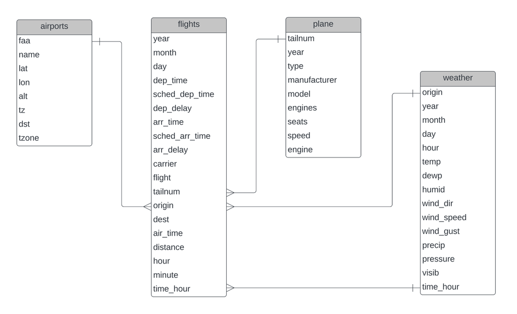

Once I was reasonably comfortable with the data and what it represented, I began to review the questions Newark Airport had included in their briefing to me relating to delays and the weather:

- what effect does the weather have on flight departure delays?
- how serious are weather related delays?
- what types of weather impacts delays the most?

Stepping back from the detail of the questions posed by Newark Airport, the question in my head became:

“What’s the best mechanism to link the data provided to departure delays?”

The question was one of cause and effect. Can we use the weather data to predict delays in departure times?

**Linear regression**  
My first thought was to approach this problem using a linear regression model. Linear regression seeks to predict a numeric response (in this case it would be delay time) by quantifying the size and strength of the relationship between numerical values (delay time and weather metric values).

My attempt to define a linear regression model for delays and weather data proved inconclusive. On reflection I realised that whilst linear regression is suited to predicting the value of a numeric variable based on its relationship to one or more independent variables, the delay associated with a plane departing an airport cannot possibly have a linear relationship to such a random series of independent variables. Their impact on delay is changeable and dependent on a myriad of combinations of these variables. A straight line can’t be fitted to such data so trying to predict a value for delay with a linear regression model just isn’t appropriate.

I realised that in these circumstances it would be better to categorise the outcome of the analysis (the dependent variable) as having only two values: `delay` or `no-delay`. Such an approach is perfectly suited to **logistic regression**. I detail my approach to logistic regression and findings of my analysis in the **Predictive Analysis** section below.

**Cleaning**  
Prior to starting my analysis I reviewed the data sets I would be using and sought to clean the data where possible, isolating data that related to Newark Airport, removing variables that were not needed and reviewing the nature of missing values.

Missing values can either be removed or imputed. My approach is to keep as many observations as possible so deletion is always a last resort.

**Data enrichment**  
Once the data has been cleaned, the question becomes “can I enrich the data?”, either from another source or by calculating variables derived from the existing data. As noted earlier my attempts to find additonal weather data proved fruitless. However, I was able to enrich the `flights` data by calculating two measures of “busy-ness” from the existing variables. These additions to the data set were used in a later analysis, detailed below.

Once data enrichment and cleaning had been completed, I began to build my models.

**Iteration**  
Note that the above data analysis process whilst presented in a linear fashion it is invariably not linear in practice. It tends to be iterative, as you work with the data and learn more about it, you can return to earlier stages in your analysis and update these to reflect your improved understanding of the data and the questions being asked.

#### Tools for data analysis

I outlined my initial thoughts on paper and once I had refined these sufficiently began to work in `RStudio`. I also made use of the Lucid website (`https://lucid.app`) to draw relationships between the datasets and the `ggplot` package in `RStudio` to generate visualisations. These were the only tools I used during my work on the Newark Airport assignment.

#### Predictive Analysis

Whilst linear regression seeks to predict a numeric response, logistic regression seeks to predict the probability of a particular outcome. Instead of trying to predict the *value* of delay time, a logistic regression model would seek to predict the *probability* that a flight would be delayed. That is, given a set of weather events at a particular time, what is the probability that a flight departing at that same time, will be delayed?

**Logistic regression** is a classification modelling technique. Whilst the output of linear regression is a predicted value, the output of logistic regression is a categorical response. In this instance, `DELAY` or `NO DELAY`. Logistic regression uses a nonlinear function to model the relationship between the independent variables and the categorical response (predicted variable). This ensures that the output is always between 0 and 1 for all possible combination of input values.

##### (1) Weather related delays

Turning to the first set of questions from Newark Airport concerning departure delays and the impact of weather on these.

- what effect does the weather have on flight departure delays?
- how serious are weather related delays?
- what types of weather impacts delays the most?

To begin to answer these questions, data relating to Newark Airport had to be selected from each of the available data sets, where appropriate.

**Flight data**  
Flights leaving Newark Airport can be extracted from the main flights dataset (`flights_data`) after joining with `airports_data` and filtering on Newark Airport’s full name, “Newark Liberty International Airport”.

The `newark_flights` data contains 26 variables with 115,968 observations.

```
## Rows: 115,968
## Columns: 26
## $ year           <dbl> 2017, 2017, 2017, 2017, 2017, 2017, 2017, 2017, 2017, 2…
## $ month          <dbl> 10, 10, 10, 10, 10, 10, 10, 10, 10, 10, 10, 10, 10, 10,…
## $ day            <dbl> 1, 1, 1, 1, 1, 1, 1, 1, 1, 1, 1, 1, 1, 1, 1, 1, 1, 1, 1…
## $ dep_time       <dbl> 27, 519, 544, 552, 555, 555, 556, 556, 607, 618, 618, 6…
## $ sched_dep_time <dbl> 2114, 525, 545, 600, 607, 600, 600, 600, 615, 625, 625,…
## $ dep_delay      <dbl> 193, -6, -1, -8, -12, -5, -4, -4, -8, -7, -7, -9, -6, 3…
## $ arr_time       <dbl> 317, 741, 815, 846, 831, 841, 802, 653, 827, 903, 906, …
## $ sched_arr_time <dbl> 15, 759, 819, 850, 853, 902, 815, 720, 844, 911, 912, 7…
## $ arr_delay      <dbl> 182, -18, -4, -4, -22, -21, -13, -27, -17, -8, -6, -2, …
## $ carrier        <chr> "UA", "UA", "B6", "NK", "UA", "AA", "DL", "WN", "UA", "…
## $ flight         <dbl> 1537, 1161, 27, 521, 1465, 1301, 575, 884, 1115, 2321, …
## $ tailnum        <chr> "N54711", "N37287", "N547JB", "N675NK", "N17229", "N3BM…
## $ origin         <chr> "EWR", "EWR", "EWR", "EWR", "EWR", "EWR", "EWR", "EWR",…
## $ dest           <chr> "MIA", "IAH", "MCO", "FLL", "DFW", "MIA", "ATL", "MDW",…
## $ air_time       <dbl> 148, 183, 133, 156, 187, 143, 103, 99, 303, 179, 155, 1…
## $ distance       <dbl> 1085, 1400, 937, 1065, 1372, 1085, 746, 711, 2227, 1372…
## $ hour           <dbl> 21, 5, 5, 6, 6, 6, 6, 6, 6, 6, 6, 6, 6, 6, 6, 6, 6, 7, …
## $ minute         <dbl> 14, 25, 45, 0, 7, 0, 0, 0, 15, 25, 25, 28, 30, 0, 41, 3…
## $ time_hour      <dttm> 2017-10-01 21:00:00, 2017-10-01 05:00:00, 2017-10-01 0…
## $ name           <chr> "Newark Liberty International Airport", "Newark Liberty…
## $ lat            <dbl> 40.6925, 40.6925, 40.6925, 40.6925, 40.6925, 40.6925, 4…
## $ lon            <dbl> -74.1687, -74.1687, -74.1687, -74.1687, -74.1687, -74.1…
## $ alt            <dbl> 18, 18, 18, 18, 18, 18, 18, 18, 18, 18, 18, 18, 18, 18,…
## $ tz             <dbl> -5, -5, -5, -5, -5, -5, -5, -5, -5, -5, -5, -5, -5, -5,…
## $ dst            <chr> "A", "A", "A", "A", "A", "A", "A", "A", "A", "A", "A", …
## $ tzone          <chr> "America/New_York", "America/New_York", "America/New_Yo…
```

Some of the data is superfluous and is repeated for each entry so we can remove details of Newark Airport such as the `name` and `latitude` and `longitude` and altitude, time zone, daylight saving and departing airport (`alt`, `tz`, `dst`, `tzone`, `origin`).

Instead of the day number represented by `day`, it might be beneficial to include a variable for the the day name to capture the days of the week. This can be extracted from `time_hour`. As such the current `day` variable should be removed as should `year` as each observation is for the same year.

The `hour` and `time_hour` variable captures sufficient information about the scheduled departure time so `dep_time` can be removed as can `sched_dep_time`. The `minute` variable is also superfluous.

The arrival times, both scheduled and actual, and arrival delay are not predictor variables as they are a consequence of any delay on departure so can be removed.

The flight number (`flight`) also does not have a predictive quality. It doesn’t describe the departure or the circumstances at the time of departure, so should be removed.

From this, we reduce the number of variables from 26 to 10.

```
## Rows: 115,968
## Columns: 10
## $ month     <dbl> 10, 10, 10, 10, 10, 10, 10, 10, 10, 10, 10, 10, 10, 10, 10, …
## $ dep_delay <dbl> 193, -6, -1, -8, -12, -5, -4, -4, -8, -7, -7, -9, -6, 33, -8…
## $ carrier   <chr> "UA", "UA", "B6", "NK", "UA", "AA", "DL", "WN", "UA", "AA", …
## $ tailnum   <chr> "N54711", "N37287", "N547JB", "N675NK", "N17229", "N3BMAA", …
## $ dest      <chr> "MIA", "IAH", "MCO", "FLL", "DFW", "MIA", "ATL", "MDW", "LAS…
## $ air_time  <dbl> 148, 183, 133, 156, 187, 143, 103, 99, 303, 179, 155, 111, 8…
## $ distance  <dbl> 1085, 1400, 937, 1065, 1372, 1085, 746, 711, 2227, 1372, 102…
## $ hour      <dbl> 21, 5, 5, 6, 6, 6, 6, 6, 6, 6, 6, 6, 6, 6, 6, 6, 6, 7, 6, 7,…
## $ time_hour <dttm> 2017-10-01 21:00:00, 2017-10-01 05:00:00, 2017-10-01 05:00:…
## $ day       <ord> Sun, Sun, Sun, Sun, Sun, Sun, Sun, Sun, Sun, Sun, Sun, Sun, …
```

There are a number of missing values across the dataset. Logistic regression is intolerant of missing values. It can’t model the size and strength of a relationship with missing values.

```
##     month dep_delay   carrier   tailnum      dest  air_time  distance      hour
##         0      2903         0       722         0      3266         0         0
## time_hour       day
##         0         0
```

Before acting on these, we start by looking at the statistical distribution (summary statistics) of the values for each of the three variables.

```
##    dep_delay         tailnum             air_time
##  Min.   : -25.00   Length:115968      Min.   : 20.0
##  1st Qu.:  -6.00   Class :character   1st Qu.: 97.0
##  Median :  -2.00   Mode  :character   Median :136.0
##  Mean   :  15.59                      Mean   :161.6
##  3rd Qu.:  14.00                      3rd Qu.:208.0
##  Max.   :1217.00                      Max.   :696.0
##  NA's   :2903                         NA's   :3266
```

The amount of time the flight spends in the air (`air_time`) has a considerable number of missing values. These could be considered erroneous but more likely they indicate that the flight has been cancelled. A new variable (`cancelled`) with values `TRUE` and `FALSE` could be added to capture this information allowing the `NA` (missing) values within `air_time` to be converted to a zero value. This would allow another regression model to be constructed to predict cancellations. For the moment, we will remove the `NA` values within `air_time` but make a mental note for future reference.

For `dep_delay` we can use mean imputation to resolve the missing values. After which, the summary statistics reamin relatively unchanged for `dep_delay`.

```
##    dep_delay
##  Min.   : -25.00
##  1st Qu.:  -6.00
##  Median :  -2.00
##  Mean   :  15.51
##  3rd Qu.:  14.00
##  Max.   :1217.00
```

For the remaining `tailnum` variable, I replace missing values with “ABCXYZ”.

The result of all this cleaning is a new dataset, `newark_flights_clean`, which contains no missing values.

```
##     month dep_delay   carrier   tailnum      dest  air_time  distance      hour
##         0         0         0         0         0         0         0         0
## time_hour       day
##         0         0
```

The number of observations has reduced by the number of `NAs` or cancelled flights (3,266) captured within `air_time`. There are now 112,702 observations.

```
## [1] 112702     10
```

*Outliers*  
Logistic regression models are sensitive to outliers within the dataset.

Turning first to the `newark_flights_clean` data.

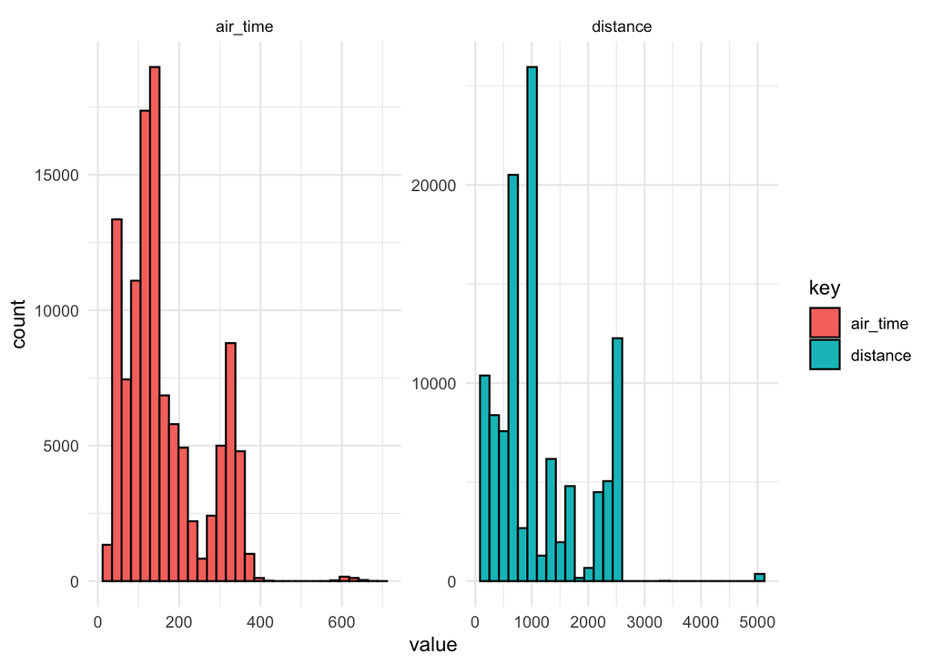

There is a skew in both the `air_time` and `distance` data within the flights dataset. This is due to departing flights to Honolulu in Hawaii.

As a rule-of-thumb, the skew may be resolved by removing any value that is larger (right skew) or less than (left skew) 1.5 times the interquartile range (IQR). Quartiles divide an ordered set of values in to four equal parts. The IQR of a set of values is the difference between the values for the first quartile (Q1) and the third quartile (Q3). The value for Q1 is the middle number between the smallest number and the median whilst the Q3 value is the middle number between the median and the highest number.

Applying this rule-of-thumb to the `newark_flights_clean` data we only lose 716 observations and the range of values for each of these variables is much reduced.

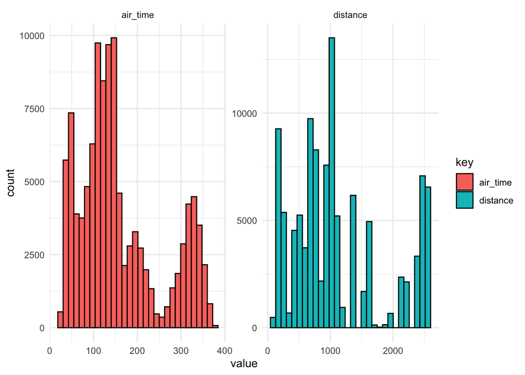

*Dependent variable*  
There is currently no dependent variable (class) in the `newark_flights_clean` dataset. We need to add one as logistic regression requires it. Newark Airport are interested in departure delays. Although the US aviation authority (The FAA) state that flights departing with less than a 15 minute delay are deemed to be ‘on time’, we will classify all flights with a departure delay of greater than 0 as being delayed. The new column will be called `delayed` and have the value of `TRUE` or `FALSE`. Once added we can remove the `dep_delay` variable.

**Weather data**  
Weather observations relating to Newark Airport can be extracted from the larger `weather_data` sample by filtering on “EWR”, the FAA code for Newark Airport.

The newark weather data contains 15 variables with 8,735 observations.

```
## Rows: 8,735
## Columns: 15
## $ origin     <chr> "EWR", "EWR", "EWR", "EWR", "EWR", "EWR", "EWR", "EWR", "EW…
## $ year       <dbl> 2017, 2017, 2017, 2017, 2017, 2017, 2017, 2017, 2017, 2017,…
## $ month      <dbl> 1, 1, 1, 1, 1, 1, 1, 1, 1, 1, 1, 1, 1, 1, 1, 1, 1, 1, 1, 1,…
## $ day        <dbl> 1, 1, 1, 1, 1, 1, 1, 1, 1, 1, 1, 1, 1, 1, 1, 1, 1, 1, 1, 1,…
## $ hour       <dbl> 0, 1, 2, 3, 4, 5, 6, 7, 8, 9, 10, 11, 12, 13, 14, 15, 16, 1…
## $ temp       <dbl> NA, NA, NA, NA, NA, NA, NA, NA, NA, NA, NA, NA, NA, NA, NA,…
## $ dewp       <dbl> NA, NA, NA, NA, NA, NA, NA, NA, NA, NA, NA, NA, NA, NA, NA,…
## $ humid      <dbl> NA, NA, NA, NA, NA, NA, NA, NA, NA, NA, NA, NA, NA, NA, NA,…
## $ wind_dir   <dbl> 200, 220, 190, 190, 220, 220, NA, 230, 230, 230, 220, 220, …
## $ wind_speed <dbl> 17.26170, 16.11092, 11.50780, 8.05546, 9.20624, 11.50780, N…
## $ wind_gust  <dbl> 19.864419, 18.540125, 13.242946, 9.270062, 10.594357, 13.24…
## $ precip     <dbl> NA, NA, NA, NA, NA, NA, NA, NA, NA, NA, NA, NA, NA, NA, NA,…
## $ pressure   <dbl> NA, NA, NA, NA, NA, NA, NA, NA, NA, NA, NA, NA, NA, NA, NA,…
## $ visib      <dbl> 10, 10, 10, 10, 10, 10, 10, 10, 10, 10, 10, 10, 10, 10, 10,…
## $ time_hour  <dttm> 2017-01-01 08:00:00, 2017-01-01 09:00:00, 2017-01-01 10:00…
```

Despite an extensive internet search I could not find free access to hourly weather data for Newark Airport to supplement the provided data set.

There are a number of missing values across the weather dataset.

```
##     origin       year      month        day       hour       temp       dewp
##          0          0          0          0          0       8531       8531
##      humid   wind_dir wind_speed  wind_gust     precip   pressure      visib
##       8531        629        617        617       8266       8564          3
##  time_hour
##          0
```

All of these variables are numeric.

Before cleaning, we start by looking at the summary statistics.

```
##       year          month             day             hour           temp
##  Min.   :2017   Min.   : 1.000   Min.   : 1.00   Min.   : 0.0   Min.   :32.00
##  1st Qu.:2017   1st Qu.: 4.000   1st Qu.: 8.00   1st Qu.: 6.0   1st Qu.:50.00
##  Median :2017   Median : 7.000   Median :16.00   Median :12.0   Median :61.55
##  Mean   :2017   Mean   : 6.511   Mean   :15.68   Mean   :11.5   Mean   :60.51
##  3rd Qu.:2017   3rd Qu.: 9.500   3rd Qu.:23.00   3rd Qu.:17.5   3rd Qu.:70.00
##  Max.   :2017   Max.   :12.000   Max.   :31.00   Max.   :23.0   Max.   :91.00
##                                                                 NA's   :8531
##       dewp          humid           wind_dir       wind_speed
##  Min.   : 7.0   Min.   : 11.76   Min.   :  0.0   Min.   : 0.000
##  1st Qu.:32.0   1st Qu.: 36.83   1st Qu.: 70.0   1st Qu.: 5.754
##  Median :46.9   Median : 60.75   Median :210.0   Median : 8.056
##  Mean   :43.4   Mean   : 59.48   Mean   :182.7   Mean   : 8.929
##  3rd Qu.:54.0   3rd Qu.: 84.34   3rd Qu.:270.0   3rd Qu.:11.508
##  Max.   :73.9   Max.   :100.00   Max.   :360.0   Max.   :39.127
##  NA's   :8531   NA's   :8531     NA's   :629     NA's   :617
##    wind_gust          precip         pressure        visib
##  Min.   : 0.000   Min.   :0.000   Min.   :1007   Min.   : 0.130
##  1st Qu.: 6.622   1st Qu.:0.000   1st Qu.:1013   1st Qu.:10.000
##  Median : 9.270   Median :0.010   Median :1016   Median :10.000
##  Mean   :10.275   Mean   :0.018   Mean   :1016   Mean   : 9.338
##  3rd Qu.:13.243   3rd Qu.:0.020   3rd Qu.:1018   3rd Qu.:10.000
##  Max.   :45.026   Max.   :0.290   Max.   :1037   Max.   :10.000
##  NA's   :617      NA's   :8266    NA's   :8564   NA's   :3
```

The following variables have so many missing entries (recorded as `NAs`) that it makes no sense to impute values for them and they should just be removed from the dataset: `temp`, `dewp`, `humid`, `precip` and `pressure`.

In addition, `origin` should also be removed as the value for all observations is “EWR”, the FAA airport code for Newark Airport.

Variables `year`, `month`, `day` and `hour` are already included within `time_hour` so can be safely removed.

The missing values for `wind_dir`, `wind_speed`, `wind_gust` and `visib` should be imputed with mean values.

The summary statistics should remain relatively unchanged for these variables, which they do.

```
##     wind_dir       wind_speed       wind_gust          visib
##  Min.   :  0.0   Min.   : 0.000   Min.   : 0.000   Min.   : 0.130
##  1st Qu.: 90.0   1st Qu.: 5.754   1st Qu.: 6.621   1st Qu.:10.000
##  Median :190.0   Median : 8.929   Median :10.275   Median :10.000
##  Mean   :182.7   Mean   : 8.929   Mean   :10.275   Mean   : 9.338
##  3rd Qu.:270.0   3rd Qu.:11.508   3rd Qu.:13.243   3rd Qu.:10.000
##  Max.   :360.0   Max.   :39.127   Max.   :45.026   Max.   :10.000
```

There are now no missing values within the `newark_weather_clean` dataset.

```
##   wind_dir wind_speed  wind_gust      visib  time_hour
##          0          0          0          0          0
```

For the retained variables there has been no loss of data - there are still 8,735 observations.

```
## [1] 8735    5
```

*Outliers*

Outliers in the newark weather dataset.

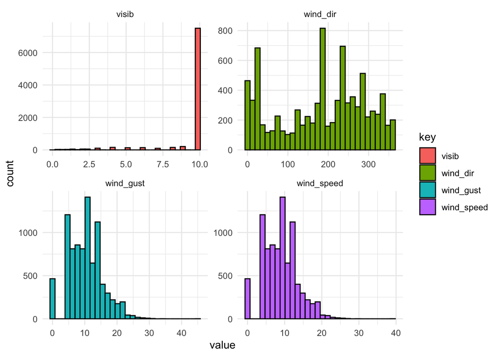

Wind direction (`wind_dir`) is not skewed so we will retain all of those observations. Visibility (`visib`) has a limited range of values and so will be excluded from quantile reduction, otherwise “10” miles will be the only value remaining for `visib`. For the `wind_speed` and `wind_gust` we will remove those values more than 1.5 times the IQR.

We lose 120 observations and the range of values for both of the wind variables is much reduced.

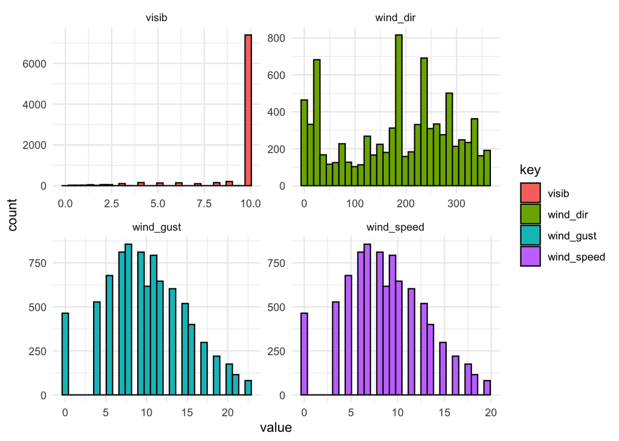

**Flight delays and Weather**  
We want to examine the impact of weather on delays at Newark Airport, so we should join the cleaned weather data to the cleaned flights data set using the `time-hour` variable which is common in both sets of data.

The (inner) join results in a loss of 1,204 observations from the `newark_flights_clean` dataset of 111,986 or a 1% loss in data. The losses occur where there is no weather data for the `time_hour` specified in the flights data.

*Splitting the dataset*  
We now want to create a training set of data for our model. Once we have trained the model to recognise (we hope) when weather causes a flight delay, we can then test the efficacy of the model on the remaining data, the test set.

We want to make sure that the class distribution of the data in the samples mimics that of the original data set. By class distribution, we refer to the value of the dependent variable (`delayed`) be it `TRUE` or `FALSE` and the number of each in the set of data.

```r
# class distribution in original dataset
round(prop.table(table(select(newark_weather_delays, delayed), exclude = NULL)), 3) * 100
```

```
## delayed
## FALSE  TRUE
##  61.6  38.4
```

```r
# class distribution in training set
round(prop.table(table(select(weather_delays_train, delayed), exclude = NULL)), 3) * 100
```

```
## delayed
## FALSE  TRUE
##  61.5  38.5
```

```r
# class distribution in test set
round(prop.table(table(select(weather_delays_test, delayed), exclude = NULL)), 3) * 100
```

```
## delayed
## FALSE  TRUE
##  61.9  38.1
```

There is a slight class imbalance in the training data set. Ideally we would like to have a balanced data set for the model to learn from otherwise it will be skewed towards the dominant class in the data, which in our example is a FALSE (or negative) result for `delayed`. The imbalance is not massively significant so we will continue but make a note for further model development in the future.

*Training the model*  
Let’s build the model using the training set of data and call the model `weather_delays_mod1`.

```r
weather_delays_mod1 <- glm(formula = delayed ~ ., data = weather_delays_train, family = binomial(link = "logit"))
```

*Evaluating the model*  
We get a detailed description of the model using the `summary()` function.

```
##
## Call:
## glm(formula = delayed ~ ., family = binomial(link = "logit"),
##     data = weather_delays_train)
##
## Deviance Residuals:
##     Min       1Q   Median       3Q      Max
## -1.3197  -0.9656  -0.9591   1.4017   1.4233
##
## Coefficients: (1 not defined because of singularities)
##               Estimate Std. Error z value Pr(>|z|)
## (Intercept)  3.163e-01  3.837e-02   8.244   <2e-16 ***
## wind_dir     3.914e-05  7.124e-05   0.549   0.5827
## wind_speed   3.325e-03  1.878e-03   1.770   0.0767 .
## wind_gust           NA         NA      NA       NA
## visib       -8.778e-02  3.930e-03 -22.336   <2e-16 ***
## ---
## Signif. codes:  0 '***' 0.001 '**' 0.01 '*' 0.05 '.' 0.1 ' ' 1
##
## (Dispersion parameter for binomial family taken to be 1)
##
##     Null deviance: 110709  on 83085  degrees of freedom
## Residual deviance: 110195  on 83082  degrees of freedom
## AIC: 110203
##
## Number of Fisher Scoring iterations: 4
```

The coefficients error regarding singularities is most likely due to multicollinearity, or a perfect linear relationship existing between two of the variables.

We can produce a correlation matrix to see this.

```
##             wind_dir wind_speed  wind_gust      visib
## wind_dir   1.0000000 0.39175211 0.39175211 0.20764788
## wind_speed 0.3917521 1.00000000 1.00000000 0.07253247
## wind_gust  0.3917521 1.00000000 1.00000000 0.07253247
## visib      0.2076479 0.07253247 0.07253247 1.00000000
```

We can see that `wind_speed` and `wind_gust` are perfectly correlated (value = 1.0). Let’s drop `wind_speed` from the model and re-run it.

```r
weather_delays_mod2 <- glm(formula = delayed ~ wind_dir + wind_gust + visib,
                           family = binomial(link = "logit"),
                           data = weather_delays_train)
```

```
##
## Call:
## glm(formula = delayed ~ wind_dir + wind_gust + visib, family = binomial(link = "logit"),
##     data = weather_delays_train)
##
## Deviance Residuals:
##     Min       1Q   Median       3Q      Max
## -1.3197  -0.9656  -0.9591   1.4017   1.4233
##
## Coefficients:
##               Estimate Std. Error z value Pr(>|z|)
## (Intercept)  3.163e-01  3.837e-02   8.244   <2e-16 ***
## wind_dir     3.914e-05  7.124e-05   0.549   0.5827
## wind_gust    2.889e-03  1.632e-03   1.770   0.0767 .
## visib       -8.778e-02  3.930e-03 -22.336   <2e-16 ***
## ---
## Signif. codes:  0 '***' 0.001 '**' 0.01 '*' 0.05 '.' 0.1 ' ' 1
##
## (Dispersion parameter for binomial family taken to be 1)
##
##     Null deviance: 110709  on 83085  degrees of freedom
## Residual deviance: 110195  on 83082  degrees of freedom
## AIC: 110203
##
## Number of Fisher Scoring iterations: 4
```

Of the weather variables, visibility (`visib`) has a very small `p-value` denoted by Pr(>|z|) and is the only statistically significant weather variable (indicated by the 3-stars) as a predictor of flight delays.

The coefficient of each variable is quoted in log-odds. For every unit increase in the value of `visib`, the log-odds of `delayed` being `TRUE` changes by approximately -0.08. In terms of odds, we have to exponeniate the coefficient as follows:

```
##     visib
## 0.9159594
```

*Predictive accuracy*  
We need to assess the preformance of our model (which is based on training data) in predicting the dependent or response variable for observations in the test data set. This is data the model has not seen so acts as a proxy for the model’s general applicability against unseen data.

To assess model performance, we create a ‘confusion matrix’ which shows the interaction between the predicted and actual values. We assume a probability threshold of 0.5 for `TRUE`.

```
##  delayed FALSE TRUE
##    FALSE 16567  566
##     TRUE 10000  563
```

The correct predictions of the model are top left (True Negatives) and bottom right (True Positives) of the table.

The accuracy of the `weather_delays` model = (TP + TN) / Total Observations = 62%.

Given that only one weather variable is statistically significant, this result is surprisingly good.

*Other diagnostics*  
The predictive accuracy of the model must be seen in light of other diagnostic variables captured by the `summary()` function above.

Lastly, the receiver operating characteristic (ROC) curve is a single graphical representation of the effectiveness of a logistic regression model.

A model with no predictive value would be represented by a line at 45 degrees.

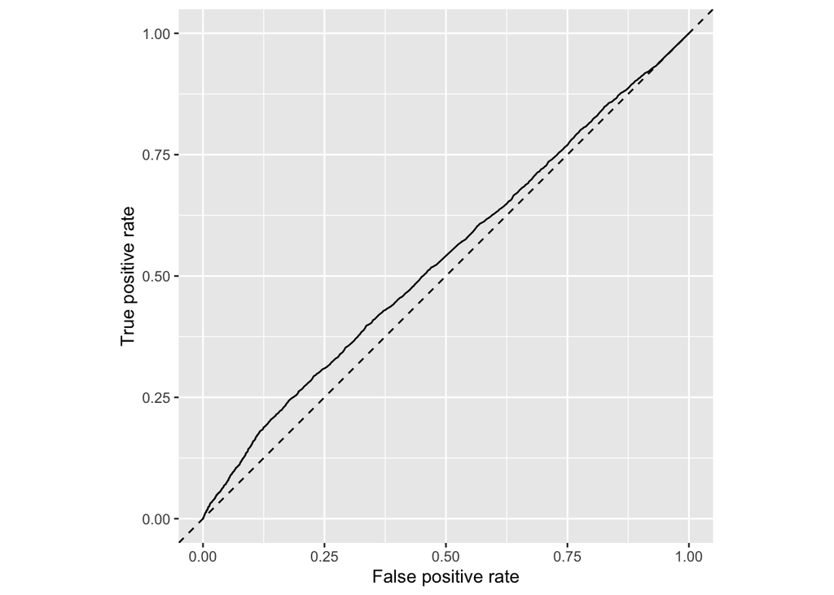

The weather model produces a predictive curve that is very close to 45 degrees.

The area under the curve (AUC) can be measured as 54%:

```
## Area under the curve: 0.5355
```

*Conclusions*  
Whilst the predictive accuracy of the model is reasonably high, most flights are not delayed so the accuracy is bouyed by defaulting to the common outcome.

The model is weak as indicated by the null and residual deviance scores having little divergence. They also appear to be high in value.

The AIC value also appears to be high especially when compared to models detailed later in this paper.

In terms of weather, the most impactful variable is visibility. It is the only statistically significant predictor variable in the model. This makes perfect sense. We know from our own anecdotal experience, poor visibility often plays a factor in plane crashes reported in the media. The pilot is human and still relies on his own eyesight as much as the instruments on the dashboard in front of him.

Lastly, the AUC score for the model is barely above that of a 45 degree line, indicating poor predictive capability. Regardless of visibility, the weather would not appear to be a factor in determining departure delays from Newark Airport.

##### (2) Other factors impacting delays

Having looked at the impact of the weather on flight delays we turn now to consider other factors which may also delay take-off at Newark Airport.

Returning to the `newark_flights_clean` dataset, we should look to supplement this data by:

- adding data about the plane
- capturing a measure of ‘busy-ness’ regarding flights that day or hour

Once complete, we could create another model and assess its predictive quality.

Let’s firstly look at additional information we can glean concerning the planes departing Newark Airport.

**Plane data**

```
## Rows: 3,521
## Columns: 9
## $ tailnum      <chr> "N102AA", "N103AA", "N103SY", "N10575", "N105AA", "N105SY…
## $ year         <dbl> 2007, 2007, 2014, 2002, 1978, 2014, 2014, 2014, 1977, 201…
## $ type         <chr> "Fixed wing single engine", "Fixed wing single engine", "…
## $ manufacturer <chr> "AVIAT AIRCRAFT INC", "AVIAT AIRCRAFT INC", "EMBRAER S A"…
## $ model        <chr> "A-1B", "A-1B", "ERJ 170-200 LR", "EMB-145LR", "R182", "E…
## $ engines      <dbl> 1, 1, 2, 2, 1, 2, 2, 2, 1, 2, 1, 2, 1, 2, 2, 2, 2, 2, 2, …
## $ seats        <dbl> 2, 2, 88, 55, 4, 88, 88, 88, 2, 88, 2, 88, 2, 88, 55, 55,…
## $ speed        <dbl> NA, NA, NA, NA, 111, NA, NA, NA, NA, NA, NA, NA, NA, NA, …
## $ engine       <chr> "Reciprocating", "Reciprocating", "Turbo-fan", "Turbo-fan…
```

Of interest are the following variables:

- `tailnum` to link the table to the flights data
- `year` from which we can determine the age of the plane in 2017. Perhaps older planes break down more often.
- `engines` tells us how many engines the plane has and how many engines could go wrong
- `seats` informs us as to the capacity of the plane and so the potential for passenger related delays
- `engine` there are only 8 types of engine which allow us to highlight if there are recurring faults with a particular engine type

Let’s clean the plane data of which there are 3,521 observations and 9 variables.

```
## [1] 3521    9
```

Check for missing values.

```
##      tailnum         year         type manufacturer        model      engines
##            0          102            0            0            0            0
##        seats        speed       engine
##           10         3459            0
```

Of our variables of interest `year` and `seats` are missing values. We can’t impute these values so we should remove the offending observations.

We should also remove the `speed` variable as this has a huge number of missing values.

```
## tailnum    year engines   seats  engine
##       0       0       0       0       0
```

Let’s calculate the age of the plane and add this to the dataset.

```r
plane_data_clean <- plane_data_clean %>%
  mutate(age = 2017 - year)
```

```
## Rows: 3,419
## Columns: 6
## $ tailnum <chr> "N102AA", "N103AA", "N103SY", "N10575", "N105AA", "N105SY", "N…
## $ year    <dbl> 2007, 2007, 2014, 2002, 1978, 2014, 2014, 2014, 1977, 2014, 20…
## $ engines <dbl> 1, 1, 2, 2, 1, 2, 2, 2, 1, 2, 1, 2, 1, 2, 2, 2, 2, 2, 2, 2, 2,…
## $ seats   <dbl> 2, 2, 88, 55, 4, 88, 88, 88, 2, 88, 2, 88, 2, 88, 55, 55, 55, …
## $ engine  <chr> "Reciprocating", "Reciprocating", "Turbo-fan", "Turbo-fan", "R…
## $ age     <dbl> 10, 10, 3, 15, 39, 3, 3, 3, 40, 3, 10, 3, 10, 3, 15, 15, 13, 1…
```

*Outliers*  
Let’s examine `plane_data_clean` for outliers.

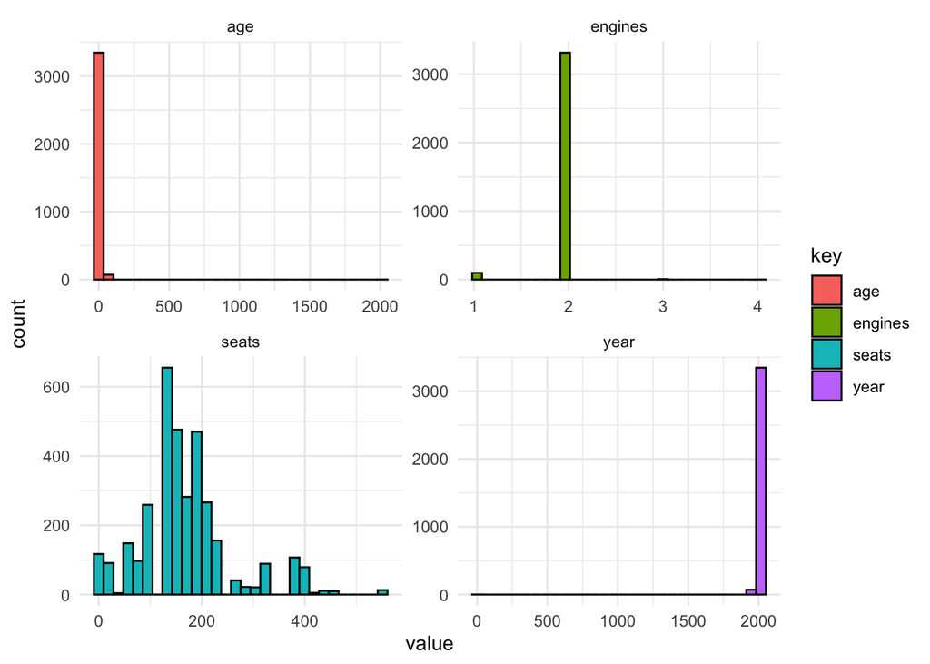

There are clear discrepancies in `age` and `year`.

Sorting the data by age reveals there is a zero value rather than a missing value in `year`. We need to remove this.

```
## # A tibble: 5 × 6
##   tailnum  year engines seats engine          age
##   <chr>   <dbl>   <dbl> <dbl> <chr>         <dbl>
## 1 N111AA      0       2    10 Turbo-prop     2017
## 2 N172AA   1954       1     4 Reciprocating    63
## 3 N381AA   1956       4   102 Reciprocating    61
## 4 N183AA   1958       2     5 Reciprocating    59
## 5 N199AA   1958       1     5 Reciprocating    59
```

After which the range of the variables becomes more normal.

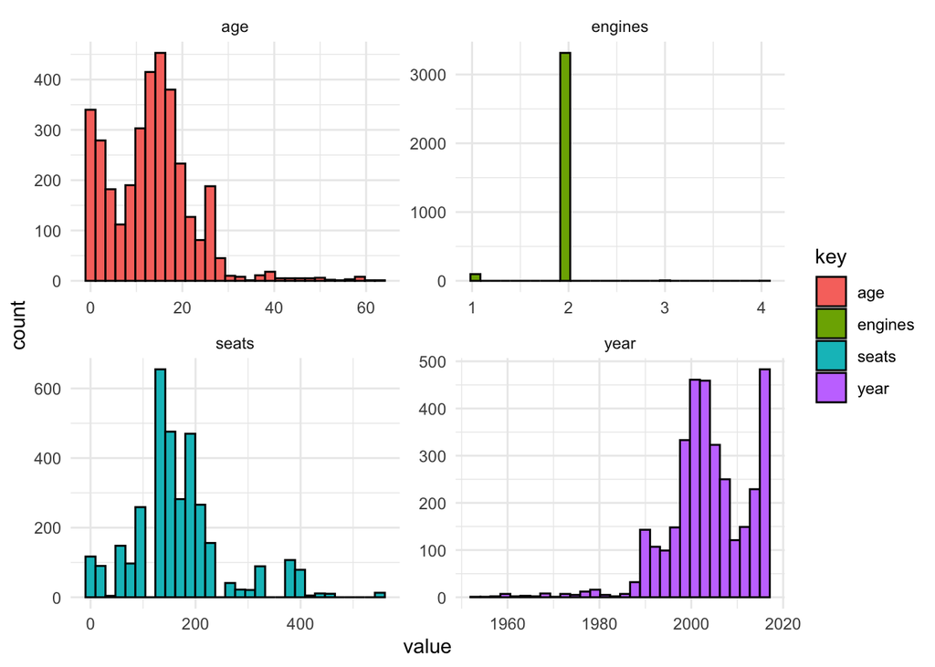

We can now remove `year` from `plane_data_clean`.

**Flights data**

Returning to the flights data.

*Measure of busy-ness*  
We should look to capture a measure of busy-ness in the flights data.

How many flights are taking off that day? That hour?

We can calculate values for each of these variables and add them to the data set.

```r
# measures of busy-ness in newark flights data
newark_flights_clean <- newark_flights_clean %>%
  mutate(date = as.Date(time_hour)) %>%
  group_by(date) %>%
  mutate(departures_in_day = n()) %>%
  ungroup()

newark_flights_clean <- newark_flights_clean %>%
  group_by(time_hour) %>%
  mutate(departures_in_hour = n()) %>%
  ungroup()
```

```
## Rows: 111,986
## Columns: 13
## $ month              <dbl> 10, 10, 10, 10, 10, 10, 10, 10, 10, 10, 10, 10, 10,…
## $ delayed            <lgl> TRUE, FALSE, FALSE, FALSE, FALSE, FALSE, FALSE, FAL…
## $ carrier            <chr> "UA", "UA", "B6", "NK", "UA", "AA", "DL", "WN", "UA…
## $ tailnum            <chr> "N54711", "N37287", "N547JB", "N675NK", "N17229", "…
## $ dest               <chr> "MIA", "IAH", "MCO", "FLL", "DFW", "MIA", "ATL", "M…
## $ air_time           <dbl> 148, 183, 133, 156, 187, 143, 103, 99, 303, 179, 15…
## $ distance           <dbl> 1085, 1400, 937, 1065, 1372, 1085, 746, 711, 2227, …
## $ hour               <dbl> 21, 5, 5, 6, 6, 6, 6, 6, 6, 6, 6, 6, 6, 6, 6, 6, 6,…
## $ time_hour          <dttm> 2017-10-01 21:00:00, 2017-10-01 05:00:00, 2017-10-…
## $ day                <ord> Sun, Sun, Sun, Sun, Sun, Sun, Sun, Sun, Sun, Sun, S…
## $ date               <date> 2017-10-01, 2017-10-01, 2017-10-01, 2017-10-01, 20…
## $ departures_in_day  <int> 305, 305, 305, 305, 305, 305, 305, 305, 305, 305, 3…
## $ departures_in_hour <int> 17, 2, 2, 16, 16, 16, 16, 16, 16, 16, 16, 16, 16, 1…
```

Check for outliers in new busy-ness variables.

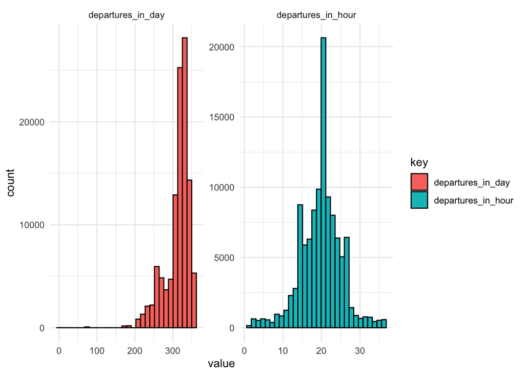

`departures_in_day` is skewed left so we should reduce the range of values in this variable.

```r
# remove outliers from departures_in_day
newark_flights_clean <- newark_flights_clean %>%
  mutate(min_departures_in_day = quantile(departures_in_day, 0.75) -
           (1.5 * IQR(departures_in_day))) %>%
  filter(departures_in_day >= min_departures_in_day) %>%
  select(-c(min_departures_in_day))
```

The outliers have been removed from `departures_in_day` at a cost of 20,475 observations (down from 111,986 to 91,511), about 18% of the dataset.

After which the range of the variables becomes more normal.

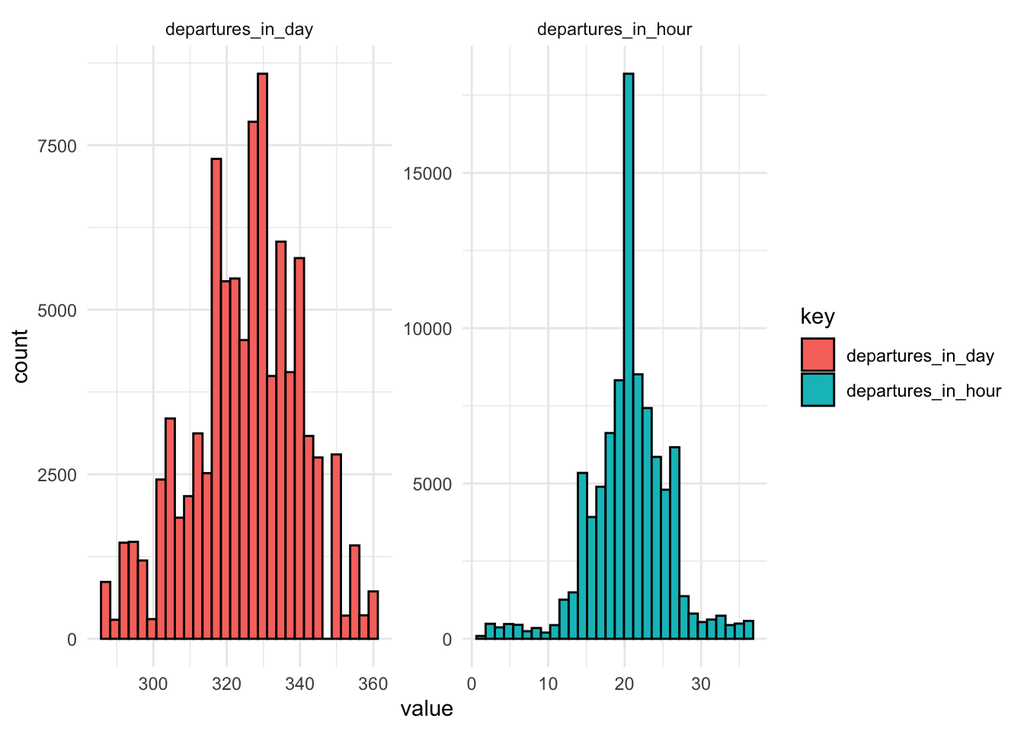

**Flight delays and Other Factors**  
We combine `newark_flights_clean` with `plane_data_clean`. We can then build another model to examine the impact of ‘other factors’ on delays at Newark Airport.

```r
newark_other_delays <-
  inner_join(newark_flights_clean, plane_data_clean, by = "tailnum") %>%
  select(-date, -tailnum) # remove unwanted variables
```

We lose 7,802 observations with the inner join on the plane data, down to 83,709.

*Splitting the dataset*  
Again, we want to create a training set of data for our model which we can then test on the remaining data, the test set.

We want to make sure that the class distribution of the data in the samples mimics that of the original data set.

```
## delayed
## FALSE  TRUE
##  60.3  39.7
```

```
## delayed
## FALSE  TRUE
##  60.4  39.6
```

```
## delayed
## FALSE  TRUE
##  60.1  39.9
```

There is a slight class imbalance in the training data set. The imbalance is not massively significant so we continue.

*Training the model*  
We build the model using the training set of data.

```r
other_delays_mod1 <- glm(formula = delayed ~ ., data = other_delays_train, family = binomial(link = "logit"))
```

*Evaluating the model*

```
##
## Call:
## glm(formula = delayed ~ ., family = binomial(link = "logit"),
##     data = other_delays_train)
##
## Deviance Residuals:
##     Min       1Q   Median       3Q      Max
## -2.3340  -0.9277  -0.5969   1.0550   2.7281
##
## Coefficients: (1 not defined because of singularities)
##                       Estimate Std. Error z value Pr(>|z|)
## (Intercept)          1.375e+02  1.761e+01   7.810 5.74e-15 ***
## month                1.878e-01  3.121e-02   6.016 1.79e-09 ***
## carrierAS            1.556e-02  1.895e-01   0.082 0.934543
## carrierB6            7.473e-01  1.714e-01   4.359 1.30e-05 ***
## carrierDL            3.509e-01  1.792e-01   1.958 0.050229 .
## carrierEV            5.946e-01  1.797e-01   3.310 0.000933 ***
## carrierNK           -4.446e-01  1.839e-01  -2.419 0.015584 *
## carrierOO            7.771e-01  1.926e-01   4.036 5.45e-05 ***
## carrierUA            1.313e-01  1.670e-01   0.786 0.431870
## carrierVX            4.469e-01  1.823e-01   2.451 0.014240 *
## carrierWN            8.854e-01  1.745e-01   5.075 3.87e-07 ***
## destATL              1.129e+00  4.374e-01   2.581 0.009846 **
## destAUS              1.936e+00  4.600e-01   4.210 2.56e-05 ***
## destAVL              9.809e-01  4.586e-01   2.139 0.032447 *
## destAVP              2.208e-01  4.642e-01   0.476 0.634262
## destBDL              6.240e-02  4.603e-01   0.136 0.892161
## destBGR              9.459e-01  4.511e-01   2.097 0.036003 *
## destBNA              1.243e+00  4.394e-01   2.828 0.004677 **
## destBOS              6.221e-01  4.309e-01   1.444 0.148839
## destBQN              1.993e+00  4.826e-01   4.130 3.63e-05 ***
## destBTV              4.943e-01  4.355e-01   1.135 0.256395
## destBUF              5.075e-01  4.361e-01   1.164 0.244580
## destBWI              5.092e-01  4.424e-01   1.151 0.249728
## destBZN              2.226e+00  7.887e-01   2.823 0.004757 **
## destCAK              7.854e-01  4.392e-01   1.788 0.073769 .
## destCHA              1.198e+00  4.432e-01   2.702 0.006884 **
## destCHS              1.158e+00  4.393e-01   2.635 0.008401 **
## destCLE              5.904e-01  4.337e-01   1.361 0.173368
## destCLT              8.368e-01  4.540e-01   1.843 0.065289 .
```

[output cut: 85 more lines]

```
## engineTurbo-fan     -6.274e-01  7.913e-01  -0.793 0.427855
## engineTurbo-jet     -9.802e-01  8.002e-01  -1.225 0.220577
## engineTurbo-prop    -3.549e-01  9.397e-01  -0.378 0.705682
## engineTurbo-shaft    9.931e-01  8.364e-01   1.187 0.235079
## age                  1.108e-02  1.735e-03   6.384 1.72e-10 ***
## ---
## Signif. codes:  0 '***' 0.001 '**' 0.01 '*' 0.05 '.' 0.1 ' ' 1
##
## (Dispersion parameter for binomial family taken to be 1)
##
##     Null deviance: 84299  on 62780  degrees of freedom
## Residual deviance: 74405  on 62663  degrees of freedom
## AIC: 74641
##
## Number of Fisher Scoring iterations: 9
```

*Improving the model*  
The `NAs` returned for `distance` indicate that multicollinearity exists in the model. That is, two or more predictor variables are highly (or perfectly) correlated. We can generate a correlation matrix to see the inter-relationship of the numerical variables. In this instance it is likely that there is a high correlation between `distance` and `air_time`.

```
##           air_time  distance
## air_time 1.0000000 0.9922435
## distance 0.9922435 1.0000000
```

The correlation between the two variables is very strong (0.99). We should remove one of them from the model.

Whilst the correlation matrix can be used for numerical variables we must also consider if there are any aliased variables in the model. Again, this is another measure of correlation between variables.

```r
alias(other_delays_mod1)
```

```
## Model :
## delayed ~ month + carrier + dest + air_time + distance + hour +
##     time_hour + day + departures_in_day + departures_in_hour +
##     engines + seats + engine + age
##
## Complete :
##          (Intercept) month carrierAS carrierB6 carrierDL carrierEV carrierNK
## distance  143           0     0         0         0         0         0
##          carrierOO carrierUA carrierVX carrierWN destATL destAUS destAVL
## distance    0         0         0         0       603    1361     440
##          destAVP destBDL destBGR destBNA destBOS destBQN destBTV destBUF
## distance  -50     -27     250     605      57    1442     123     139
##          destBWI destBZN destCAK destCHA destCHS destCLE destCLT destCMH
## distance   26    1739     239     575     485     261     386     320
##          destCVG destDAY destDCA destDEN destDFW destDSM destDTW destEGE
## distance  426     390      56    1462    1229     874     345    1582
##          destFLL destFNT destFWA destGRR destGSO destGSP destHDN destIAD
## distance  922     375     435     462     302     451    1585      69
##          destIAH destIND destJAC destJAX destLAS destLAX destLEX destMCI
## distance 1257     502    1731     677    2084    2311     445     949
##          destMCO destMDW destMEM destMHT destMIA destMKE destMSN destMSP
## distance  794     568     803      66     942     582     656     865
##          destMSY destMTJ destMYR destOAK destOMA destORD destORF destPBI
## distance 1024    1652     407    2412     991     576     141     880
##          destPDX destPHX destPIT destPVD destPWM destRDU destRIC destROC
## distance 2291    1990     176      17     141     273     134     103
##          destRSW destSAN destSAT destSAV destSBN destSDF destSEA destSFO
## distance  925    2282    1426     565     494     499    2259    2422
##          destSJC destSJU destSLC destSMF destSNA destSRQ destSTL destSTT
## distance 2405    1465    1826    2357    2291     891     729    1491
##          destSYR destTPA destTVC destTYS air_time hour time_hour day.L day.Q
## distance   52     854     501     488       0        0    0         0     0
##          day.C day^4 day^5 day^6 departures_in_day departures_in_hour engines
## distance    0     0     0     0     0                 0                  0
##          seats engine4 Cycle engineReciprocating engineTurbo-fan
## distance    0     0             0                   0
##          engineTurbo-jet engineTurbo-prop engineTurbo-shaft age
## distance    0               0                0                 0
```

It’s clear that `distance` and `dest` are also highly correlated, which makes sense.

We remove `air_time` and `dest` but retain `distance` which is a more intuitive and accurate measure of length or duration, rebuild the model and evaluate the results.

```r
other_delays_mod2 <- glm(formula = delayed ~ carrier + distance + hour + day +
                           departures_in_day + departures_in_hour + engines + seats +
                           engine + age,
                         data = other_delays_train, family = binomial(link = "logit"))
```

```
##
## Call:
## glm(formula = delayed ~ carrier + distance + hour + day + departures_in_day +
##     departures_in_hour + engines + seats + engine + age, family = binomial(link = "logit"),
##     data = other_delays_train)
##
## Deviance Residuals:
##     Min       1Q   Median       3Q      Max
## -2.1529  -0.9337  -0.6180   1.0689   2.5648
##
## Coefficients:
##                       Estimate Std. Error z value Pr(>|z|)
## (Intercept)         -1.207e-01  7.981e-01  -0.151 0.879758
## carrierAS            9.158e-02  1.434e-01   0.638 0.523155
## carrierB6            9.929e-01  1.251e-01   7.934 2.12e-15 ***
## carrierDL            3.510e-01  1.279e-01   2.745 0.006058 **
## carrierEV            6.770e-01  1.256e-01   5.392 6.97e-08 ***
## carrierNK           -2.343e-01  1.396e-01  -1.679 0.093241 .
## carrierOO            7.892e-01  1.442e-01   5.472 4.45e-08 ***
## carrierUA            2.868e-01  1.222e-01   2.348 0.018894 *
## carrierVX            5.080e-01  1.378e-01   3.687 0.000227 ***
## carrierWN            1.035e+00  1.276e-01   8.110 5.08e-16 ***
## distance            -2.714e-06  1.523e-05  -0.178 0.858497
## hour                 1.684e-01  2.039e-03  82.599  < 2e-16 ***
## day.L               -5.442e-01  1.072e-01  -5.079 3.80e-07 ***
## day.Q               -9.664e-01  1.040e-01  -9.289  < 2e-16 ***
## day.C               -7.033e-01  7.858e-02  -8.951  < 2e-16 ***
## day^4               -6.451e-01  5.010e-02 -12.878  < 2e-16 ***
## day^5               -4.501e-02  2.925e-02  -1.539 0.123874
## day^6               -2.141e-02  2.219e-02  -0.965 0.334594
## departures_in_day   -1.446e-02  6.463e-04 -22.368  < 2e-16 ***
## departures_in_hour   1.738e-02  1.971e-03   8.820  < 2e-16 ***
## engines              6.438e-01  2.685e-01   2.398 0.016492 *
## seats                3.120e-03  1.865e-04  16.725  < 2e-16 ***
## engine4 Cycle       -4.614e-01  8.344e-01  -0.553 0.580273
## engineReciprocating  5.921e-01  7.376e-01   0.803 0.422119
## engineTurbo-fan     -8.576e-01  7.855e-01  -1.092 0.274917
## engineTurbo-jet     -1.306e+00  7.943e-01  -1.644 0.100078
## engineTurbo-prop    -4.568e-01  9.326e-01  -0.490 0.624221
## engineTurbo-shaft    9.386e-01  8.299e-01   1.131 0.258065
## age                  9.686e-03  1.572e-03   6.161 7.24e-10 ***
## ---
## Signif. codes:  0 '***' 0.001 '**' 0.01 '*' 0.05 '.' 0.1 ' ' 1
##
## (Dispersion parameter for binomial family taken to be 1)
##
##     Null deviance: 84299  on 62780  degrees of freedom
## Residual deviance: 75241  on 62752  degrees of freedom
## AIC: 75299
##
## Number of Fisher Scoring iterations: 4
```

We can test the collinearity of variables in the model using the `vif` function from the `car` package.

```
##                        GVIF Df GVIF^(1/(2*Df))
## carrier            8.320239  9        1.124912
## distance           1.695656  1        1.302173
## hour               1.113002  1        1.054989
## day                1.179659  6        1.013864
## departures_in_day  1.207808  1        1.099003
## departures_in_hour 1.104106  1        1.050764
## engines            3.901609  1        1.975249
## seats              2.658686  1        1.630548
## engine             5.573408  6        1.153923
## age                1.419368  1        1.191372
```

VIF stands for Variance Inflation Factor and is useful to identify correlation where it may exist between three or more variables rather than just between pairs.

A VIF of 5 or more indicates the presence of multicollinearity. We can see that `carrier` and `engine` both have values in excess of 5 and should be removed from the model.

Reviewing the summary statistics of the model shows that `hour`, `day`, `departures_in_day`, `departures_in_hour`, `seats`, `age` are statistically significant predictor variables. Whilst `carrier` is significant it fails the VIF test and is removed.

We then build a third iteration of the model and evaluate it.

```r
other_delays_mod3 <- glm(formula = delayed ~ hour + day + departures_in_day +
                           departures_in_hour + seats + age,
                         data = other_delays_train, family = binomial(link = "logit"))
```

```
##
## Call:
## glm(formula = delayed ~ hour + day + departures_in_day + departures_in_hour +
##     seats + age, family = binomial(link = "logit"), data = other_delays_train)
##
## Deviance Residuals:
##     Min       1Q   Median       3Q      Max
## -1.8756  -0.9348  -0.6411   1.0845   2.4753
##
## Coefficients:
##                      Estimate Std. Error z value Pr(>|z|)
## (Intercept)         1.2158991  0.2079229   5.848 4.98e-09 ***
## hour                0.1619834  0.0019939  81.238  < 2e-16 ***
## day.L              -0.5450848  0.1066410  -5.111 3.20e-07 ***
## day.Q              -0.9571289  0.1035243  -9.245  < 2e-16 ***
## day.C              -0.6988917  0.0781947  -8.938  < 2e-16 ***
## day^4              -0.6394858  0.0498337 -12.832  < 2e-16 ***
## day^5              -0.0449284  0.0290780  -1.545   0.1223
## day^6              -0.0199169  0.0220357  -0.904   0.3661
## departures_in_day  -0.0140955  0.0006411 -21.986  < 2e-16 ***
## departures_in_hour  0.0147150  0.0019337   7.610 2.75e-14 ***
## seats               0.0010632  0.0001164   9.135  < 2e-16 ***
## age                 0.0027645  0.0013268   2.084   0.0372 *
## ---
## Signif. codes:  0 '***' 0.001 '**' 0.01 '*' 0.05 '.' 0.1 ' ' 1
##
## (Dispersion parameter for binomial family taken to be 1)
##
##     Null deviance: 84299  on 62780  degrees of freedom
## Residual deviance: 76104  on 62769  degrees of freedom
## AIC: 76128
##
## Number of Fisher Scoring iterations: 4
```

```r
other_delays_mod4 <- glm(formula = delayed ~ hour + day + departures_in_day +
                           departures_in_hour + seats,
                         data = other_delays_train, family = binomial(link = "logit"))
```

```
##
## Call:
## glm(formula = delayed ~ hour + day + departures_in_day + departures_in_hour +
##     seats, family = binomial(link = "logit"), data = other_delays_train)
##
## Deviance Residuals:
##     Min       1Q   Median       3Q      Max
## -1.8741  -0.9346  -0.6417   1.0850   2.4812
##
## Coefficients:
##                      Estimate Std. Error z value Pr(>|z|)
## (Intercept)         1.2672244  0.2064560   6.138 8.36e-10 ***
## hour                0.1617607  0.0019904  81.272  < 2e-16 ***
## day.L              -0.5449295  0.1066529  -5.109 3.23e-07 ***
## day.Q              -0.9575388  0.1035356  -9.248  < 2e-16 ***
## day.C              -0.6988728  0.0782030  -8.937  < 2e-16 ***
## day^4              -0.6397141  0.0498380 -12.836  < 2e-16 ***
## day^5              -0.0450969  0.0290789  -1.551    0.121
## day^6              -0.0199801  0.0220355  -0.907    0.365
## departures_in_day  -0.0141069  0.0006411 -22.005  < 2e-16 ***
## departures_in_hour  0.0147640  0.0019330   7.638 2.21e-14 ***
## seats               0.0010235  0.0001148   8.917  < 2e-16 ***
## ---
## Signif. codes:  0 '***' 0.001 '**' 0.01 '*' 0.05 '.' 0.1 ' ' 1
##
## (Dispersion parameter for binomial family taken to be 1)
##
##     Null deviance: 84299  on 62780  degrees of freedom
## Residual deviance: 76108  on 62770  degrees of freedom
## AIC: 76130
##
## Number of Fisher Scoring iterations: 4
```

*Predictive accuracy*  
We need to assess the performance of our model (which is based on training data) in predicting the dependent or response variable for observations in the test data set. Again this is data the model has not yet seen and acts as a proxy for the model’s applicability against unseen data.

As with the previous `weather_delays` model we create a ‘confusion matrix’ which displays the interaction between the predicted and actual values. Again we assume a probability threshold of 0.5 for `TRUE`.

```
##  delayed FALSE TRUE
##    FALSE  9869 2713
##     TRUE  4108 4238
```

The correct predictions of the model are top left (True Negatives) and bottom right (True Positives) of the table.

Lastly, the receiver operating characteristic (ROC) curve is a single graphical representation of the effectiveness of a logistic regression model.

A model with no predictive value would be represented by a line at 45 degrees.

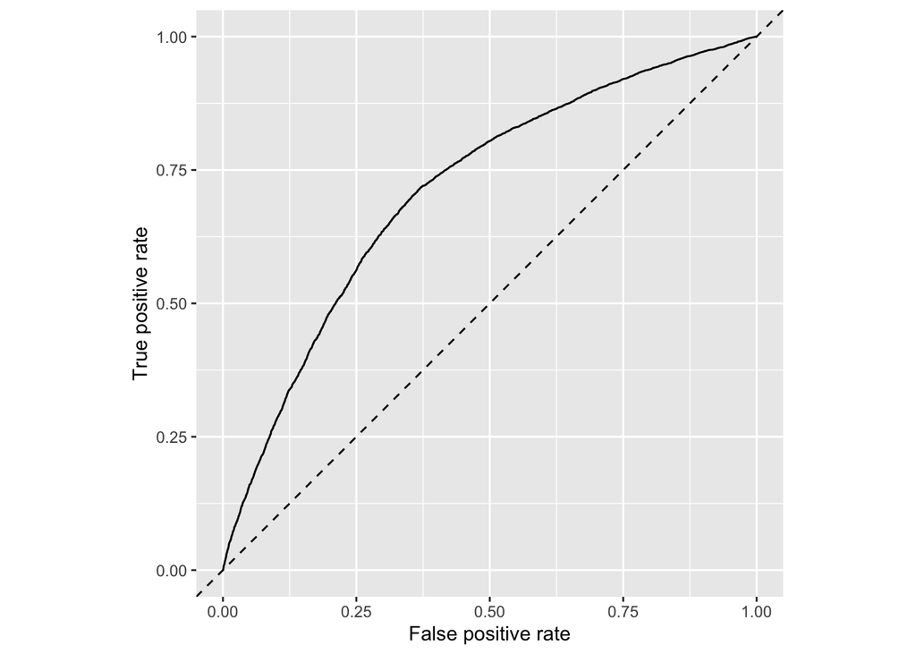

The area under the curve (AUC) can be measured as:

```
## Area under the curve: 0.7131
```

*Conclusions*  
Whilst the predictive accuracy of the final “other-delays” model is similar to the final weather model, it would appear far more robust. The null deviance scores are much improved as is the AIC value.

Most importantly, the AUC score is much improved from the weather model, up from 54% to 71% for the “other-delays” model.

This indicates the predictive ability of factors such as the `hour` and `day` of departure, the number of planes departing (`busy-ness`) and the number of `seats` on the plane are far more important predictors of delay than the weather.

##### (3) Cancelled flights model

Cancelled flights can be seeen as an extension of the delayed flights issue at Newark Airport. As noted earlier there appear to be a number of cancelled flights in the `flights` dataset denoted by `NA` values within the `air_time` variable.

```r
newark_cancelled <- newark_flights

colSums(is.na(newark_cancelled))
```

```
##     month dep_delay   carrier   tailnum      dest  air_time  distance      hour
##         0      2903         0       722         0      3266         0         0
## time_hour       day
##         0         0
```

There would appear to be 3,266 cancelled flights in the Newark flights dataset.

If we work with this assumption we can create a logistic regression model to see how well we can predict cancellations from the given data.

Firstly, we need to remove the `dep_delay` variable as this is irrelevant to flight cancellations - a flight can’t be recorded as delayed *and* cancelled.

Again, we replace the missing values within `tailnum` with “ABCXYZ”.

The only missing values in the dataset should now relate to `air_time`.

```
##     month   carrier   tailnum      dest  air_time  distance      hour time_hour
##         0         0         0         0      3266         0         0         0
##       day
##         0
```

We need to create a new variable (`cancelled`) by converting the values within `air_time` to either TRUE (for `NA` values) or FALSE, then remove the `air_time` variable.

We should also add the same busy-ness variables (`departures_in_day` and `departures_in_hour`) to the cancelled flights data we have seen in previous models.

*Outliers*  
Logistic regression is intolerant to outliers in the data so let’s remove them from the `distance` and `departures_in_delay` variables within the `cancelled_flights` dataset using the IQR adjustment as before.

```r
# remove outliers from cancelled flights data
newark_cancelled_clean <- newark_cancelled_clean %>%
  mutate(max_distance = quantile(distance, 0.75) + (1.5 * IQR(distance))) %>%
  mutate(min_departures_in_day = quantile(departures_in_day, 0.75) -
           (1.5 * IQR(departures_in_day))) %>%
  filter(distance <= max_distance) %>%
  filter(departures_in_day >= min_departures_in_day) %>%
  select(-c(max_distance, min_departures_in_day))
```

*Join cancelled dataset to weather and plane data*  
We want to join the *clean weather* and *clean plane* datasets to the *clean cancelled flights* data to create a large data set to build our cancelled model upon.

```r
newark_cancelled_weather <-
  inner_join(newark_cancelled_clean, newark_weather_clean, by = "time_hour") %>%
  select(-date, -time_hour) # remove unwanted variables

newark_cancelled_weather_other <-
  inner_join(newark_cancelled_weather, plane_data_clean, by = "tailnum") %>%
  select(-tailnum) # remove unwanted variables
```

*Splitting the dataset*  
Once joined, we again want to create a training set of data for our model which we can then test on the remaining data, the test set. First let’s examine the class imbalance in the full dataset.

```
## cancelled
## FALSE  TRUE
##  97.7   2.3
```

It is highly imbalanced. This needs correcting before we proceed to building a model.

To correct the imbalance, the `ROSE` package (Random Over-Sampling Examples) in `RStudio` requires that variables are either categorical (`as.factor`) or continuous numeric. To achieve this variables with `<chr>` data types need to be removed and all other variables converted to either `<dbl>` or `<fct>`.

We then need to split this ROSE compatible dataset into a training (75%) and test (25%) set of data.

Again the class distribution of the original data set is as follows:

```
## cancelled
## FALSE  TRUE
##  97.7   2.3
```

The class distribution of the training set will initially reflect this.

```r
# class distribution in training set
round(prop.table(table(select(cancelled_train, cancelled), exclude = NULL)), 3) * 100
```

```
## cancelled
## FALSE  TRUE
##  97.7   2.3
```

Such a stark imbalance will mean that the model will ‘learn’ to bias towards the dominant class, in this case `FALSE`. We need to re-balance the training set.

We use the ROSE package to over-sample the minority class (`TRUE`) and balance the training set.

```r
cancelled_train_ROSE <- ROSE(cancelled ~., data = cancelled_train, seed = 1)$data
# class distribution in adjusted training set
round(prop.table(table(select(cancelled_train_ROSE, cancelled), exclude = NULL)), 3) * 100
```

```
## cancelled
## FALSE  TRUE
##  49.9  50.1
```

This is now a well balanced training data set.

The test set will still reflect the make-up of the original dataset as it should.

```r
# class distribution in test set
round(prop.table(table(select(cancelled_test, cancelled), exclude = NULL)), 3) * 100
```

```
## cancelled
## FALSE  TRUE
##  97.7   2.3
```

*Training the model*  
We build the model using the now balanced training set of data.

```r
cancelled_flights_mod1 <- glm(formula = cancelled ~ ., data = cancelled_train_ROSE, family = binomial(link = "logit"))
```

*Evaluating the model*

```r
summary(cancelled_flights_mod1)
```

```
##
## Call:
## glm(formula = cancelled ~ ., family = binomial(link = "logit"),
##     data = cancelled_train_ROSE)
##
## Deviance Residuals:
##     Min       1Q   Median       3Q      Max
## -2.2724  -1.0527   0.4255   1.0195   2.4992
##
## Coefficients:
##                      Estimate Std. Error z value Pr(>|z|)
## (Intercept)        -1.145e+00  2.795e-01  -4.097 4.18e-05 ***
## month              -6.235e-02  2.485e-03 -25.090  < 2e-16 ***
## distance           -4.898e-04  1.238e-05 -39.544  < 2e-16 ***
## hour                5.402e-02  1.631e-03  33.119  < 2e-16 ***
## day                -2.982e-02  4.172e-03  -7.147 8.85e-13 ***
## departures_in_day   7.575e-03  5.565e-04  13.612  < 2e-16 ***
## departures_in_hour -2.228e-03  1.507e-03  -1.479 0.139121
## wind_dir           -8.436e-04  7.239e-05 -11.654  < 2e-16 ***
## wind_speed          1.011e-02  2.716e-03   3.722 0.000197 ***
## wind_gust           7.743e-03  2.367e-03   3.272 0.001070 **
## visib              -7.571e-02  3.491e-03 -21.688  < 2e-16 ***
## engines             3.004e-01  1.035e-01   2.903 0.003698 **
## seats              -4.004e-03  1.038e-04 -38.563  < 2e-16 ***
## age                -4.046e-02  1.319e-03 -30.677  < 2e-16 ***
## ---
## Signif. codes:  0 '***' 0.001 '**' 0.01 '*' 0.05 '.' 0.1 ' ' 1
##
## (Dispersion parameter for binomial family taken to be 1)
##
##     Null deviance: 90695  on 65422  degrees of freedom
## Residual deviance: 80828  on 65409  degrees of freedom
## AIC: 80856
##
## Number of Fisher Scoring iterations: 4
```

We can test the collinearity of variables in the model using the `vif` function from the `car` package.

```
##              month           distance               hour                day
##           1.083975           1.152473           1.055956           1.051522
##  departures_in_day departures_in_hour           wind_dir         wind_speed
##           1.102895           1.043486           1.120907           2.470030
##          wind_gust              visib            engines              seats
##           2.479475           1.051918           1.007402           1.231932
##                age
##           1.091250
```

There doesn’t appear to be significant multicollinearity in the model as no VIF values are above 5. Therefore all variables can remain.

*Predictive accuracy*  
We need to assess the preformance of our model (which is based on training data) in predicting the dependent or response variable for observations in the test data set.

```
##  cancelled FALSE TRUE
##      FALSE 13838 7478
##       TRUE   136  356
```

The correct predictions of the model are top left (True Negative) and bottom right (True Positive) of the table.

Lastly, the receiver operating characteristic (ROC) curve is a single graphical representation of the effectiveness of a logistic regression model.

A model with no predictive value would be represented by a line at 45 degrees.

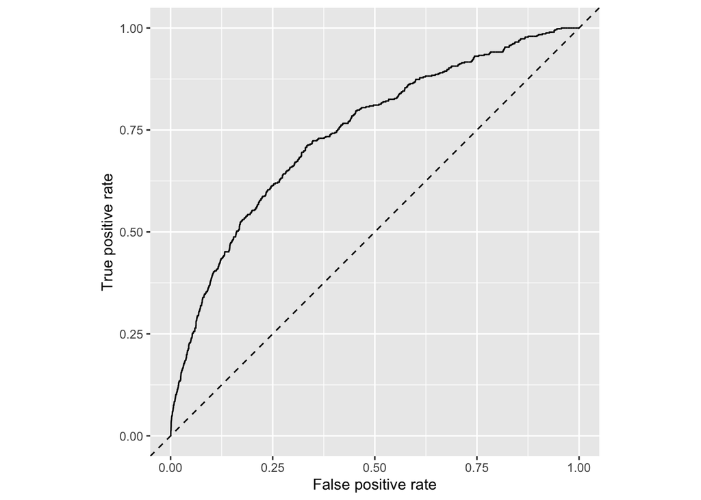

The area under the curve (AUC) can be measured as:

```
## Area under the curve: 0.742
```

*Conclusions*  
The efficacy of the “cancelled flights” model is similar to the “other delays” model in terms of predictive ability but has less robust diagnostic metrics. It also relies on more predictive variables than “other delays”.

Given the small number of flight cancellations in comparison to delays, the sample size was perhaps not large enough to build a strong “cancelled flights” model. This is despite the class bias being adjusted in the training data set.

#### Comparison of delays across New York airports

Looking more broadly at departure delays and comparison of such delays across the three major airports in NYC, we see the following trends in 2017:

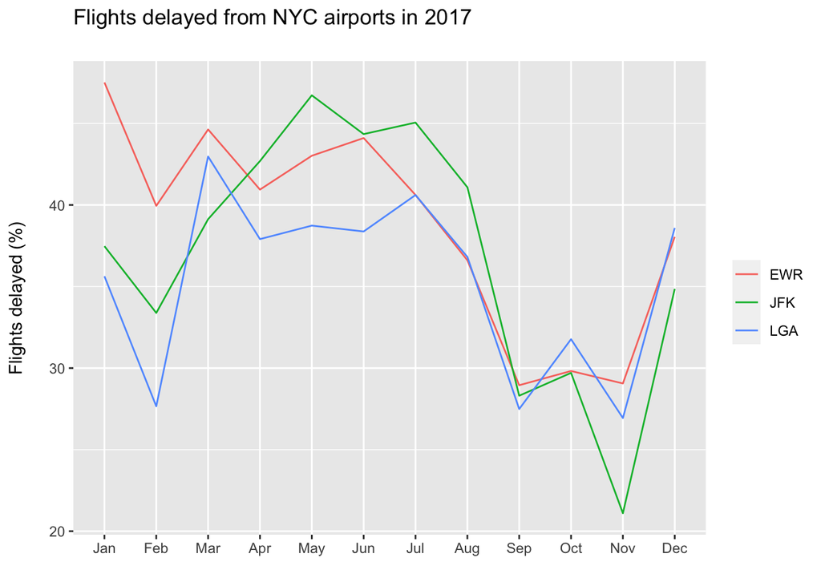

The same trend for delays is mirrored across all three airports with delays highest in the summer months whilst they peak again in Dec and Jan. In other words, the delays are highest during the main holiday periods.

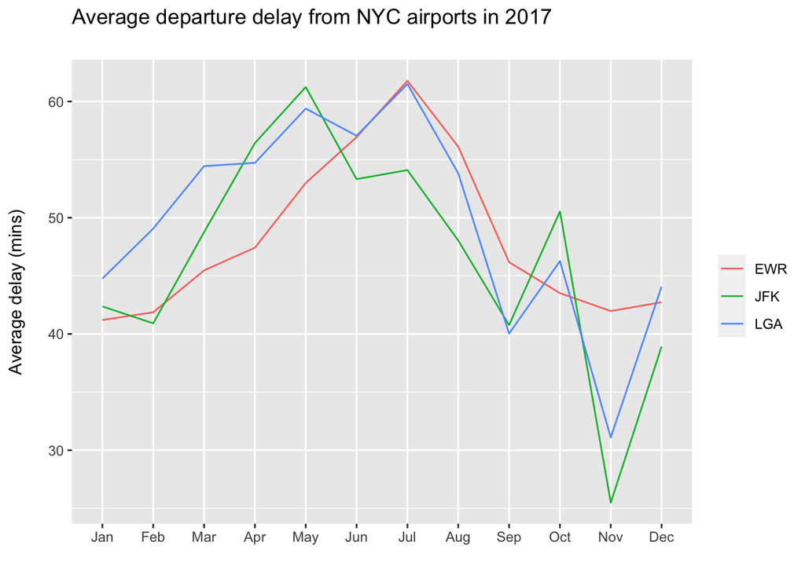

In line with the number of flights delayed, average departure delays were highest in the summer months, fall during the Autumn period but rise again during the Christmas break.

#### Conclusions and Future Work

**Conclusions**

From the limited data set available, one can conclude that the weather does not have a significant impact on flight delays.

Of the weather variables available and those with sufficient data, it was clear that only visibility could be deemed to be significant. Even then, it’s inclusion in the model added limited, if any, predictive ability.

Other factors outwith the weather were proven to have an impact on departure delays from Newark Airport. The time and day of departure were seen to have a significant impact on departure delays. In addition to this, the level of activity at the airport as well as the capacity of the departing plane were also proven to be good predictors of flight delays.

There was also scope within the dataset to identify and extension to the problem of delayed flights. That is, cancelled flights. Many variables were identified as being significant in predicting flights being cancelled. The data set for cancelled flights was small (about 3% of the departing flights data set) which may have resulted in the final model being less robust than one would have liked. A larger dataset and further work on this may provide more insight and a stronger predictive model.

In terms of comparison to the other international airports in New York, Newark Airport could be seen to have trended in-line with both JFK and La Guardia during 2017.

**Future Work**

- Larger data set: The approach detailed above could be revisited with a larger data set including all departures from Newark Airport, all arrivals and a full complement of weather data. Data really is the key to better informing the machine learning algorithm which, in turn, management can learn from.
- Cutoff value: All model predictions in this paper have assumed a 0.5 threshold to realise a `TRUE` value.  
  More work could be done to determine an optimal cutoff value and so produce a more precise value for the accuracy of each model.
- Classification with more than 2 values: In each of the models detailed above, the goal has been to produce a binary classification, `DELAY` or `NO DELAY` for each observation. However, not all flight delays are equal. A 60 minute delay is much more inconvenient than a 30 minute delay whilst a 2 hour delay is very inconvenient to say the least. Further work could be undertaken to address these issues.

  A potential approach would be to predict the length of delay for flight departures into 3 categories: small delay (< 30 mins), medium delay (31 - 60 mins) and long delay (> 60 mins). A model could be created for each category and the predicted value would be taken from the model with the highest probability factor.